# Lecture 401

[figure not shown]

2020-08-31

## Machine Learning

## Recap

**Prev**: Comparing data

- 321 Lecture Simple regression
- 322 Lecture Assessing regression assumptions
- 323 Lecture Multiple regression
- 324 Practical session

**Now**: Machine Learning

- What’s Machine Learning?
- Types
- Limitations

## Definition

*“The field of machine learning is concerned with the question of how to construct computer programs that automatically improve with experience.”*

Mitchell, T. (1997). Machine Learning. McGraw Hill.

## Origines

- **Computer Science**:
  - how to manually program computers to solve tasks
- **Statistics**:
  - what conclusions can be inferred from data
- **Machine Learning**:
  - intersection of **computer science** and **statistics**
  - how to get computers to **program themselves** from experience plus some initial structure
  - effective data capture, store, index, retrieve and merge
  - computational tractability

Mitchell, T.M., 2006. The discipline of machine learning (Vol. 9). Pittsburgh, PA: Carnegie Mellon University, School of Computer Science, Machine Learning Department.

## Types of machine learning

Machine learning approaches are divided into two main types

- **Supervised**
  - training of a *“predictive”* model from data
  - one attribute of the dataset is used to “predict” another attribute
  - e.g., classification
- **Unsupervised**
  - discovery of *descriptive* patterns in data
  - commonly used in data mining
  - e.g., clustering

## Supervised

- Training dataset
  - input attribute(s)
  - attribute to predict
- Testing dataset
  - input attribute(s)
  - attribute to predict
- Type of learning model
- Evaluation function
  - evaluates difference between prediction and output in testing data

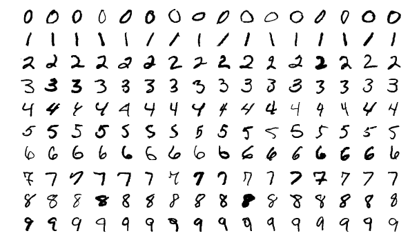

by Josef Steppan  
via Wikimedia Commons,  
CC-BY-SA-4.0

## Unsupervised

- Dataset
  - input attribute(s) to explore
- Type of model for the learning process
  - most approaches are iterative
  - e.g., hierarchical clustering
- Evaluation function
  - evaluates the quality of the pattern under consideration during one iteration

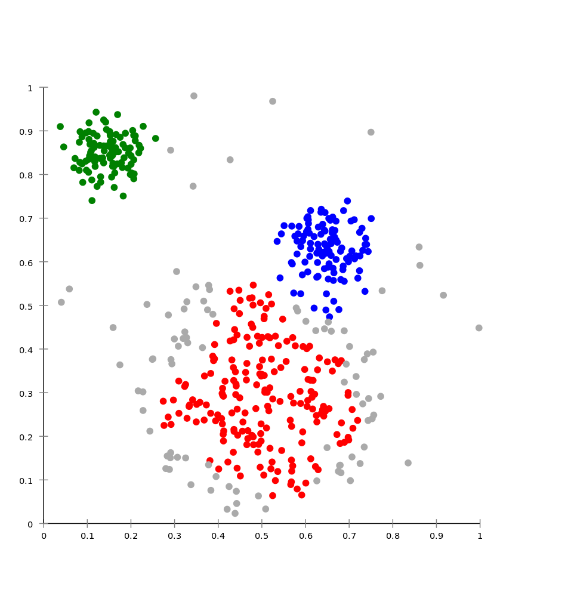

by Chire  
via Wikimedia Commons,  
CC-BY-SA-3.0

## … more

- **Semi-supervised learning**
  - between unsupervised and supervised learning
  - combines a small amount of labelled data with a larger un-labelled dataset
  - continuity, cluster, and manifold (lower dimensionality) assumption
- **Reinforcement learning**
  - training agents take actions to maximize reward
  - balancing
    - exploration (new paths/options)
    - exploitation (of current knowledge)

## Neural networks

Supervised learning approach simulating simplistic neurons

- Classic model with 3 sets
  - input neurons
  - output neurons
  - hidden layer
    - combines input values using **weights**
    - **activation function**
- The **traning algorithm** is used to define the best weights

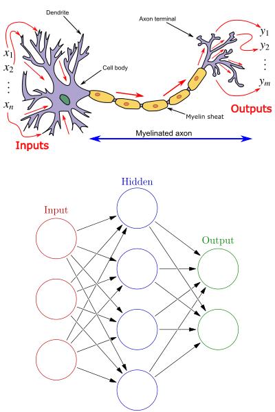

by Egm4313.s12 and Glosser.ca  
via Wikimedia Commons,  
CC-BY-SA-3.0

## Deep neural networks

Neural networks with **multiple hidden layers**

The fundamental idea is that *“deeper”* neurons allow for the encoding of more complex characteristics

**Example**: De Sabbata, S. and Liu, P. (2019). [Deep learning geodemographics with autoencoders and geographic convolution](https://www.researchgate.net/publication/334251358_Deep_learning_geodemographics_with_autoencoders_and_geographic_convolution). In proceedings of the 22nd AGILE Conference on Geographic Information Science, Limassol, Cyprus.

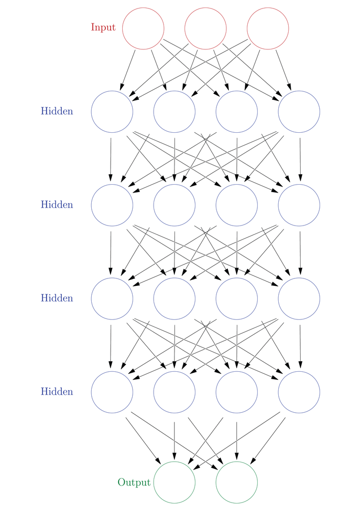

derived from work by Glosser.ca  
via Wikimedia Commons,  
CC-BY-SA-3.0

## Convolutional neural networks

Deep neural networks with **convolutional hidden layers**

- used very successfully on image object recognition
- convolutional hidden layers *“convolve”* the images
  - a process similar to applying smoothing filters

**Example**: Liu, P. and De Sabbata, S. (2019). [Learning Digital Geographies through a Graph-Based Semi-supervised Approach](https://www.researchgate.net/publication/336021293_Learning_Digital_Geographies_through_a_Graph-Based_Semi-supervised_Approach). In proceedings of the 15th International Conference on GeoComputation, Queenstown, New Zealand.

[figure not shown]

by Aphex34 via Wikimedia Commons, CC-BY-SA-4.0

## Limits

- Complexity
- Training dataset quality
  - garbage in, garbage out
  - e.g., [Facial Recognition Is Accurate, if You’re a White Guy](https://www.nytimes.com/2018/02/09/technology/facial-recognition-race-artificial-intelligence.html) by Steve Lohr (New York Times, Feb. 9, 2018)
- Overfitting
  - creating a model perfect for the training data, but not generic enough to be useful

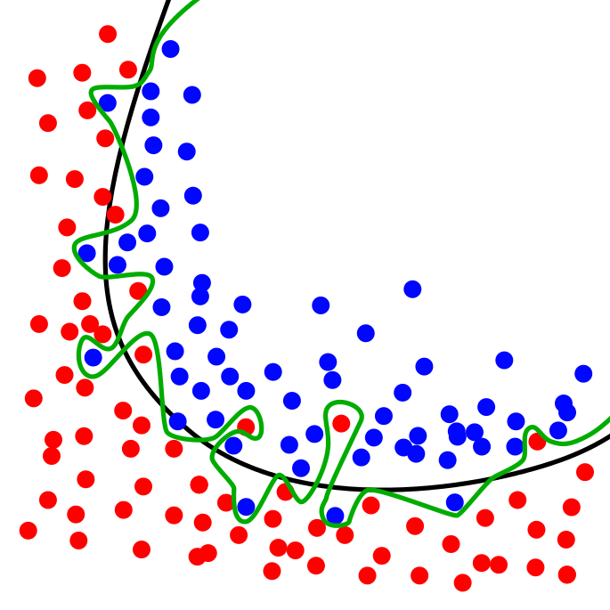

by Chabacano  
ia Wikimedia Commons,  
CC-BY-SA-4.0

## Summary

Machine Learning

- What’s Machine Learning?
- Types
- Limitations

**Next**: Centroid-based clustering

- K-means
- Fuzzy c-means
- Geodemographic classification